# Slide-deck slides

## Data Analysis/Data Visualization Report: Bike Ride Trends and Biker Types of Ford GoBike System for 2019 (february)

#### by Manpreet Kaur

## Investigation Overview

In this investigation of the Ford GoBike System, I wanted to know about how the bike usage was affected with respect to user type, age, time, and gender.

## Dataset Overview

The dataset used for this project consist of only one month data i.e. february 2019 in CSV format.

### Ride Duration before transformation

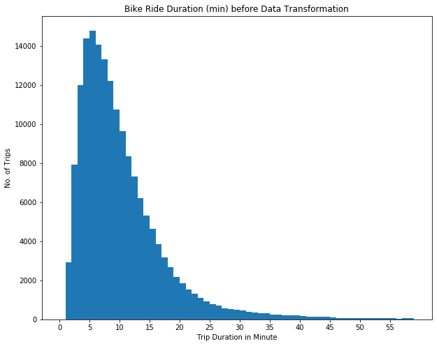

### Ride Duration after transformation

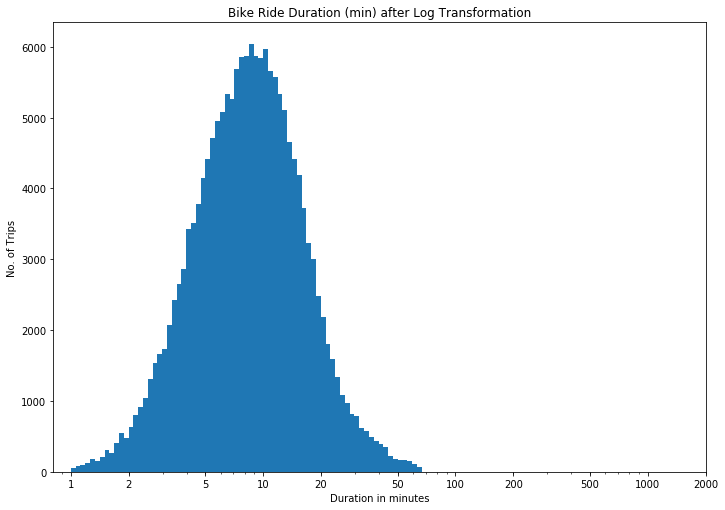

### Ford GoBike System User by Gender

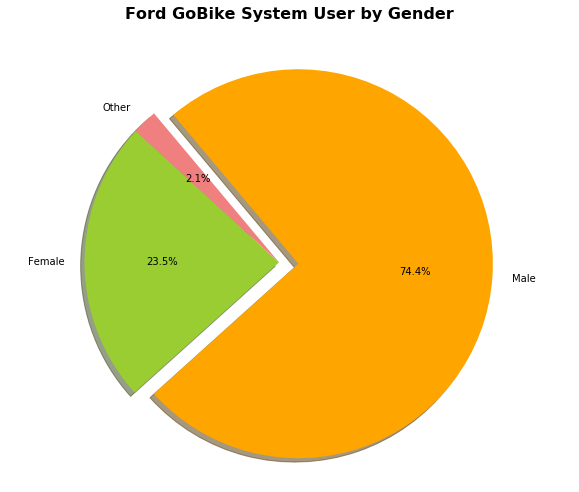

The above visualization demostrates the majority of the bike sharing system are male bikers and are about 3 times of female bikers.

### Customer vs. Subscriber Usage by Age

Below plot conveys the following things,

the first thing is y-axis is not same for the both customers and sbscribers.

Highest no. of Subscribers are of 31 years old and Most of customers are of 30 years old.

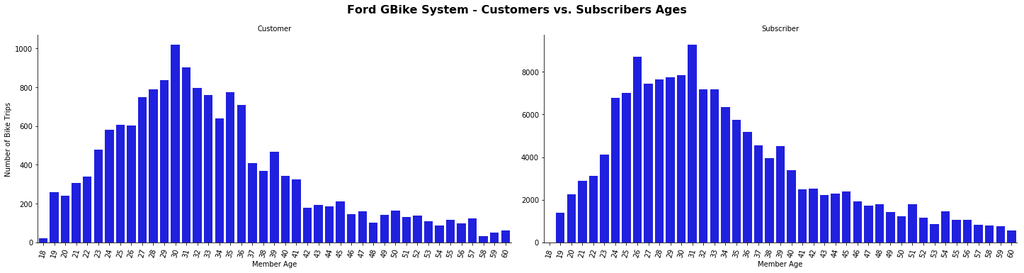

### 'Ford GoBike System - Trip Duration (Minute) per User Type and Gender

Below plot demostrates follwing;

Both female subscribers and customers take longer trips than male subscriber amnd customers.This differnce is more visible for the all three type of (female,male and others)customers as compared to subscribers.Female customers take 14 minutes of trip duration.

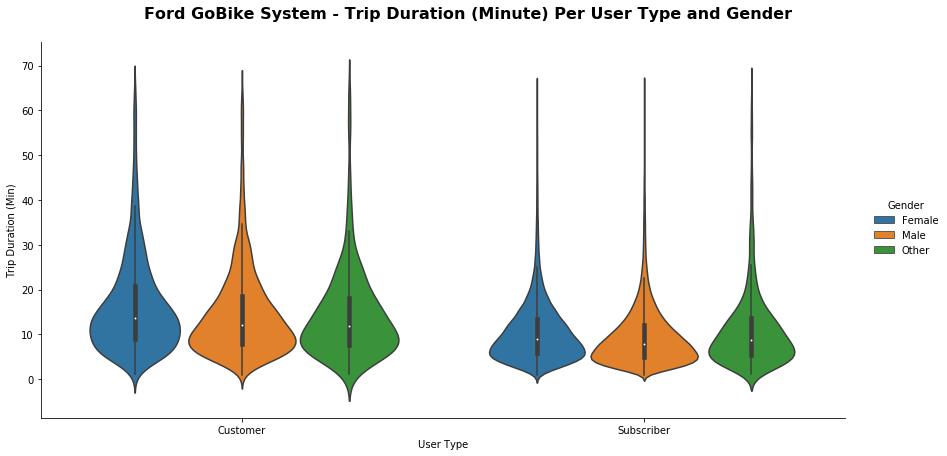

### How does the average trip duration vary in weekdays between customers and subscribers?

Below plot presents following:

Subscribers ride much shorter/quicker trips as compared to customers on each day of the week. Both user types have an obvious increase of trip duration on Saturdays and Sundays , especially for customer riders. Subscribers usage seems to be more stable and has very consistent average duration Monday through Friday than customers overall.

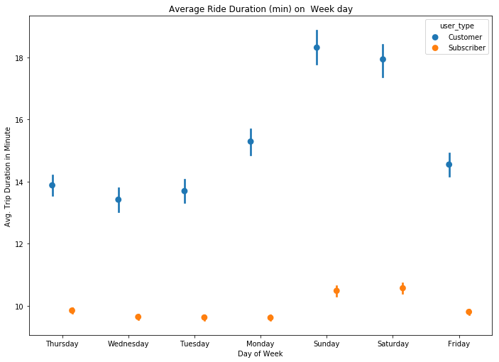

### Ford GoBike System - Summary

This project is a win - win situation and large number of prople can benefit from this bike sharing system.It has following benefits.

1.The System is eco-friendly, budget friendly, and lifetsyle friendly for both user type.

2.Affordable and convenient transportation for the people.

5.Renting a bike from theFord GoBike System is a fantastic (healthy and environmentally friendly) way of moving around in the city, both for enjoyment and work.